# Scratch gimap ReplicateVariation

Kate Isaac

2024-05-21

```r
library(gimap)
library(tidyverse)

example_data <- get_example_data("count")

example_pg_metadata <- get_example_data("meta")

example_counts <- example_data %>%
  select(c("Day00_RepA", "Day05_RepA", "Day22_RepA", "Day22_RepB", "Day22_RepC")) %>%
  as.matrix()

example_pg_id <- example_data %>%
  dplyr::select("id")

example_sample_metadata <- data.frame(
  id = 1:5,
  day = as.factor(c("Day00", "Day05", "Day22", "Day22", "Day22")),
  rep = as.factor(c("RepA", "RepA", "RepA", "RepB", "RepC"))
)

gimap_dataset <- setup_data(counts = example_counts,
                            pg_ids = example_pg_id,
                            sample_metadata = example_sample_metadata)
```

```r
qc_filter_zerocounts <- function(gimap_dataset){

  counts_filter <- unlist(lapply(1:nrow(gimap_dataset$raw_counts),
                                 function(x) 0 %in% gimap_dataset$raw_counts[x,]
                                 )
                          )

  zerocount_df <- data.frame("RawCount0" = c(FALSE, TRUE),
                             n = c(sum(!counts_filter), sum(counts_filter))
                             ) %>%
    mutate(percent = round(((n/sum(n))*100),2))

  return(list(filter = counts_filter, reportdf = zerocount_df))

}

qc_filter_output <- qc_filter_zerocounts(gimap_dataset)


eda <- example_counts[qc_filter_output$filter,c(3:5)] %>%
  cbind(example_pg_id[qc_filter_output$filter,]) %>%
  pivot_longer(starts_with("Day22"), values_to = "counts") %>%
  group_by(id) %>%
  summarize(numzero = sum(counts == 0),
            max_diff = max(counts) - min(counts),
            sec_diff = min(counts[counts > 0]) - min(counts)
            )
```

### How many day 22 pgRNAs have counts of 0 across x number of replicates

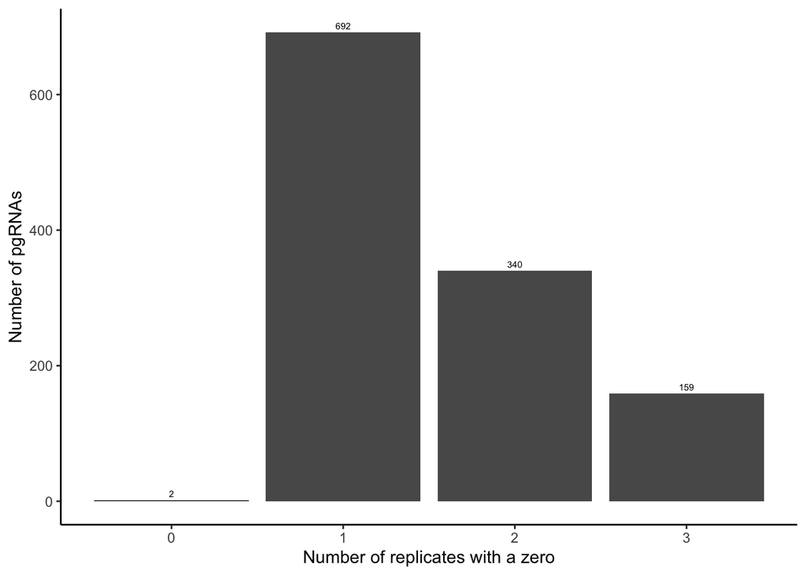

```r
countdf <- eda %>%
  group_by(numzero) %>%
  summarize(count = n())

countdf %>%
  ggplot(aes(x=numzero, y = count)) +
  geom_bar(stat="identity") +
  theme_classic() +
  ylab("Number of pgRNAs") +
  xlab("Number of replicates with a zero") +
  geom_text(aes(label = count, group = numzero), vjust = -0.5, size=2)
```

Those nearly 159 with all 3 replicates having a count of 0 could be real biological signal that we don’t want to remove or at least want to take note of for special analysis. While those with only 1 or 2 replicates with a count of 0 may have high variation and may be worth filtering.

```r
example_counts[which(example_pg_id == unlist(eda[which(eda$numzero == 0)[1],"id"])),]
```

```
## Day00_RepA Day05_RepA Day22_RepA Day22_RepB Day22_RepC
##          0         43         16         50        124
```

```r
example_counts[which(example_pg_id == unlist(eda[which(eda$numzero == 0)[2],"id"])),]
```

```
## Day00_RepA Day05_RepA Day22_RepA Day22_RepB Day22_RepC
##         32          0         28         42         57
```

The two with 0 replicates have a zero count on day 0 (KHDRBS3_nt2) and a zero count on day 5 (NXT2_nt6)

### What’s the observed differences among the replicates

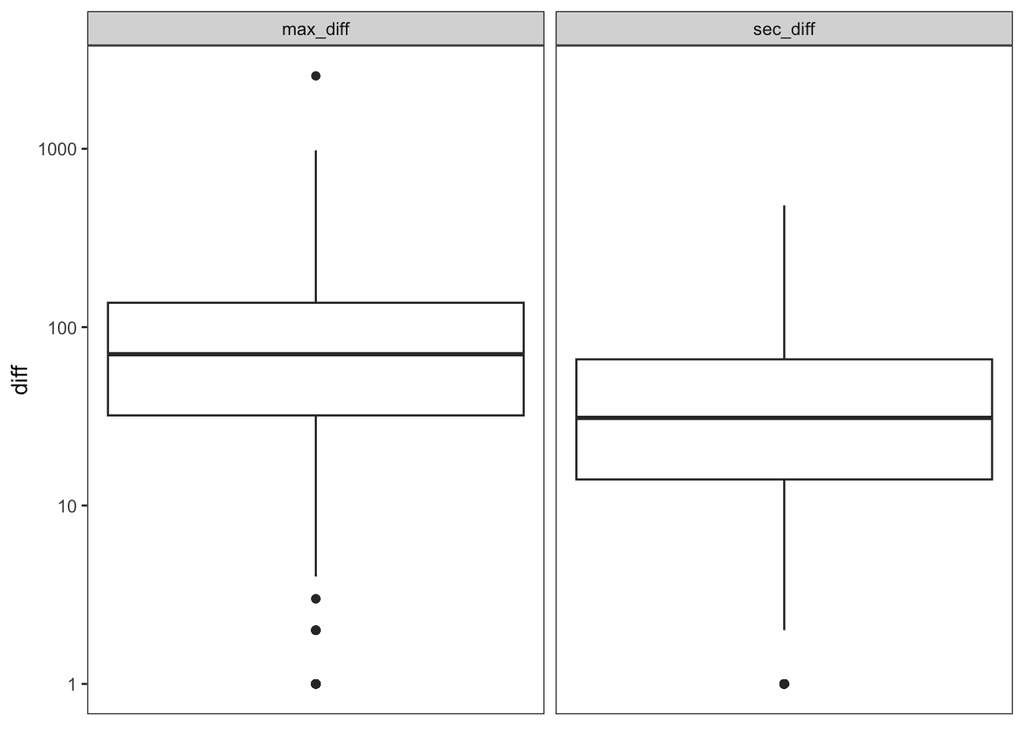

```r
eda %>%
  filter(numzero > 0) %>%
  pivot_longer(c("max_diff", "sec_diff"), values_to = "diff") %>%
  ggplot(aes(y = diff)) +
  geom_boxplot() +
  facet_wrap(~name) +
  theme_bw() +
  theme(panel.background = element_blank(),
        panel.grid = element_blank(),
        axis.title.x=element_blank(),
        axis.text.x=element_blank(),
        axis.ticks.x=element_blank()) +
  scale_y_log10()
```

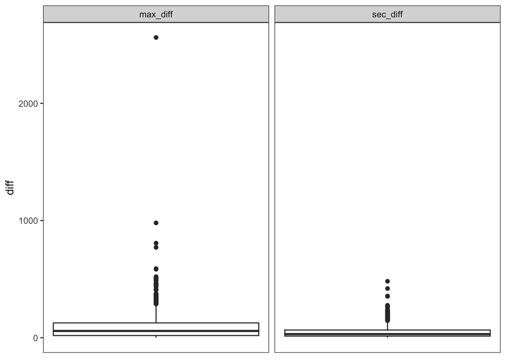

```r
eda %>%
  filter(numzero > 0) %>%
  pivot_longer(c("max_diff", "sec_diff"), values_to = "diff") %>%
  ggplot(aes(y = diff)) +
  geom_boxplot() +
  facet_wrap(~name) +
  theme_bw() +
  theme(panel.background = element_blank(),
        panel.grid = element_blank(),
        axis.title.x=element_blank(),
        axis.text.x=element_blank(),
        axis.ticks.x=element_blank())
```

```r
vardf <- gimap_dataset$transformed_data$log2_cpm[,3:5] %>%
  as.data.frame() %>%
  mutate(row = row_number()) %>%
    tidyr::pivot_longer(-row) %>%
    group_by(row) %>%
    summarize(mean = mean(value),
              var = var(value))
```

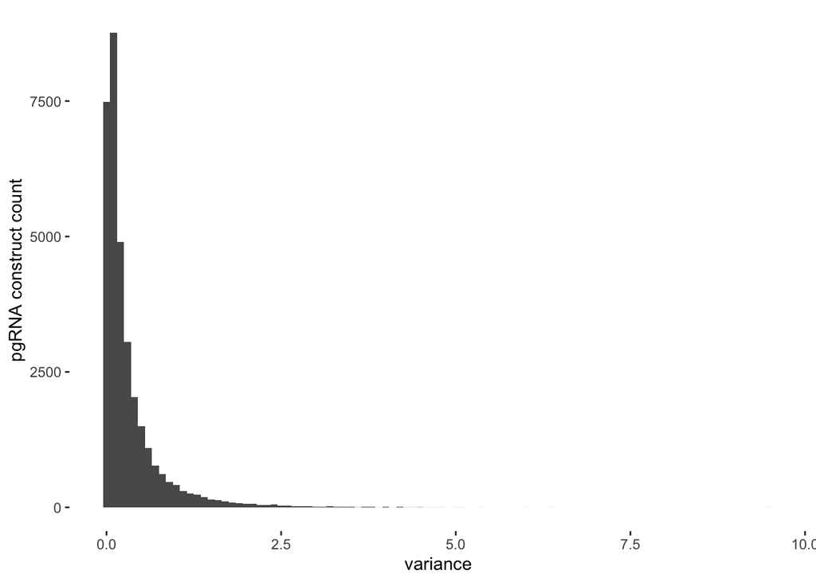

```r
vardf %>%
  ggplot(aes(x=var)) +
  geom_histogram(binwidth=0.1) +
  theme(panel.background = element_blank(),
        panel.grid = element_blank()) +
  xlab("variance") +
  ylab("pgRNA construct count")
```

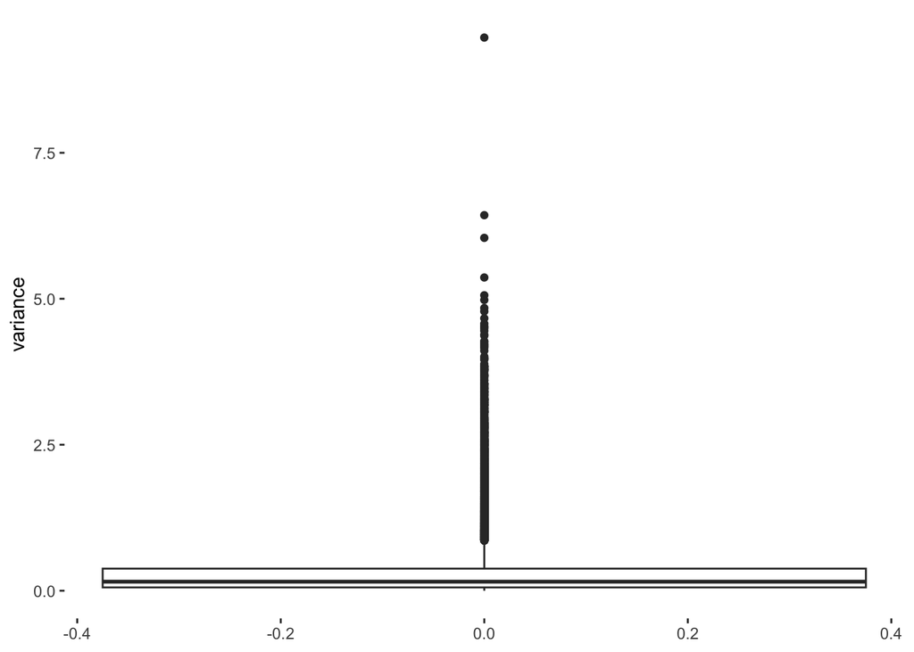

```r
vardf %>%
  ggplot(aes(y=var)) +
  geom_boxplot() +
  theme(panel.background = element_blank(),
        panel.grid = element_blank()) +
  ylab("variance")
```

Taking a similar approach to the low plasmid count filter, we construct a distribution of the variation within replicates for each pgRNA and find the quantiles as well as the upper outlier and then use the upper outlier as a potential filter value, filtering out contstructs who have a higher variance than the upper outlier.

```r
statdf <- vardf %>%
  summarize(median = median(var),
            Q1 = quantile(var, probs = 0.25),
            Q3 = quantile(var, probs = 0.75),
            upper_outlier = (Q3 + 1.5*(Q3 - Q1)))

statdf
```

```
## # A tibble: 1 × 4
##   median     Q1    Q3 upper_outlier
##    <dbl>  <dbl> <dbl>         <dbl>
## 1  0.155 0.0565 0.379         0.862
```

```r
sum(vardf$var > statdf$upper_outlier)
```

```
## [1] 2907
```